# [0]. Import Dependencies

```python
import tensorflow as tf
print(tf.__version__)

import keras
print(keras.__version__)
```

```
2.15.0
2.15.0
```

```python
!pip install --no-index --find-links=/kaggle/input/efficient-net-setup/ /kaggle/input/efficient-net-setup/efficientnet-1.1.1-py3-none-any.whl > nul 2>&1
```

```python
import os
import gc
import sys
import pickle
import numpy as np
import pandas as pd
import seaborn as sns
import tensorflow as tf
import pyarrow.parquet as pq
import matplotlib.pyplot as plt

from tqdm import tqdm
```

```python
from tensorflow.keras.constraints import Constraint
from tensorflow.keras.models import Sequential, Model
from tensorflow.keras.layers import Conv2D, BatchNormalization, MaxPooling2D, Dropout, Flatten, Dense, LSTM, Concatenate
from tensorflow.keras.layers import Input, TimeDistributed, Reshape, MaxPooling1D, Permute, Conv1D, BatchNormalization
from tensorflow.keras import layers, models

from tensorflow.keras.optimizers import Adam
import efficientnet.tfkeras as efficient_net
```

# [1]. Load Metadata & Response Data

```python
# Load train spectrogram data
filename = "/kaggle/input/hms-spectrogram-and-eeg-datasets/train_spectrograms.pkl"

# Open the file in read-binary mode
with open(filename, 'rb') as file:
    X_spect_train = pickle.load(file)

# Load validation spectrogram data
filename = "/kaggle/input/hms-spectrogram-and-eeg-datasets/val_spectrograms.pkl"

# Open the file in read-binary mode
with open(filename, 'rb') as file:
    X_spect_val = pickle.load(file)

# Load train response data
filename = "/kaggle/input/hms-spectrogram-and-eeg-datasets/y_train.pkl"

# Open the file in read-binary mode
with open(filename, 'rb') as file:
    y_train = pickle.load(file)

# Load validation response data
filename = "/kaggle/input/hms-spectrogram-and-eeg-datasets/y_val.pkl"

# Open the file in read-binary mode
with open(filename, 'rb') as file:
    y_val = pickle.load(file)
```

# [2]. Define EfficientNet Model Loading Functions

```python
def build_en(model_type, dense_layers, dense_cells, activation, lr):

    input_, base_model = None, None

    if model_type == 'B0':
        input_ = tf.keras.Input(shape = (224, 224, 3))
        base_model = efficient_net.EfficientNetB0(include_top = False, weights = None, input_shape = None)
        base_model.load_weights('/kaggle/input/tf-efficientnet-imagenet-weights/efficientnet-b0_weights_tf_dim_ordering_tf_kernels_autoaugment_notop.h5')
    elif model_type == 'B1':
        input_ = tf.keras.Input(shape = (240, 240, 3))
        base_model = efficient_net.EfficientNetB1(include_top = False, weights = None, input_shape = None)
        base_model.load_weights('/kaggle/input/tf-efficientnet-imagenet-weights/efficientnet-b1_weights_tf_dim_ordering_tf_kernels_autoaugment_notop.h5')
    elif model_type == 'B2':
        input_ = tf.keras.Input(shape = (260, 260, 3))
        base_model = efficient_net.EfficientNetB2(include_top = False, weights = None, input_shape = None)
        base_model.load_weights('/kaggle/input/tf-efficientnet-imagenet-weights/efficientnet-b2_weights_tf_dim_ordering_tf_kernels_autoaugment_notop.h5')
    elif model_type == 'B3':
        input_ = tf.keras.Input(shape = (300, 300, 3))
        base_model = efficient_net.EfficientNetB3(include_top = False, weights = None, input_shape = None)
        base_model.load_weights('/kaggle/input/tf-efficientnet-imagenet-weights/efficientnet-b3_weights_tf_dim_ordering_tf_kernels_autoaugment_notop.h5')
    elif model_type == 'B4':
        input_ = tf.keras.Input(shape = (380, 380, 3))
        base_model = efficient_net.EfficientNetB4(include_top = False, weights = None, input_shape = None)
        base_model.load_weights('/kaggle/input/tf-efficientnet-imagenet-weights/efficientnet-b4_weights_tf_dim_ordering_tf_kernels_autoaugment_notop.h5')
    else:
        raise Exception("Other models not supported.")

    # Render layers untrainable
    for layer in base_model.layers:
        layer.trainable = False

    # Create trainable portion
    x = base_model(input_)
    x = tf.keras.layers.GlobalAveragePooling2D()(x)

    if dense_layers == 1:
        x = tf.keras.layers.Dense(dense_cells[0], activation = activation)(x)
    elif dense_layers == 2:
        x = tf.keras.layers.Dense(dense_cells[0], activation = activation)(x)
        x = tf.keras.layers.Dense(dense_cells[1], activation = activation)(x)
    else:
        raise Exception("Other layer numbers not supported.")

    x = tf.keras.layers.Dense(6, activation = 'softmax', dtype = 'float32')(x)

    # Compile Model
    model = tf.keras.Model(inputs = input_, outputs = x)
    adam_optimizer = Adam(learning_rate = lr)
    loss = tf.keras.losses.KLDivergence()

    model.compile(loss = loss, optimizer = adam_optimizer)

    return model
```

```python
input_shape = (200, 600, 1)
num_classes = 6

# Define your custom data loader class
class CustomDataLoader(tf.keras.utils.Sequence):
    def __init__(self, data, labels, batch_size, img_dim):
        self.data = data
        self.labels = labels
        self.batch_size = batch_size
        self.img_dim = img_dim

    def __len__(self):
        return int(np.ceil(len(self.data) / self.batch_size))

    def __getitem__(self, index):
        start_index = index * self.batch_size
        end_index = min((index + 1) * self.batch_size, len(self.data))

        batch_data = self.data[start_index:end_index, :]
        batch_labels = self.labels.iloc[start_index:end_index, :]

        batch_data = np.expand_dims(batch_data, axis = -1)
        batch_data = tf.image.resize(batch_data, [self.img_dim, self.img_dim])
        batch_data = tf.repeat(batch_data, repeats = 3, axis = -1)

        batch_data = tf.convert_to_tensor(batch_data)      # Convert numpy array to TensorFlow tensor
        batch_labels = tf.convert_to_tensor(batch_labels)  # Convert numpy array to TensorFlow tensor

        return batch_data, batch_labels
```

```python
def val_data_processor(X_spect_val, img_dim):

    # Convert to tensors
    X_spect_val_mod = np.expand_dims(X_spect_val, axis = -1)
    X_spect_val_mod = tf.convert_to_tensor(X_spect_val_mod, dtype = tf.float32)
    X_spect_val_mod = tf.image.resize(X_spect_val_mod, [img_dim, img_dim])
    X_spect_val_mod = tf.repeat(X_spect_val_mod, repeats = 3, axis = -1)

    return X_spect_val_mod

y_val = tf.convert_to_tensor(y_val, dtype = tf.float32)
```

# [3]. Train Efficient Net Transfer Learning Models

A corpus of 17,000 images is not sufficient to train a Convolutional Neural Network (CNN) from scratch effectively, due to the high chance of overfitting. CNNs tend to have extremely large numbers of trainable parameters, and without very heavy regularization, a CNN can easily learn to perfectly identify any image in a small training corpus. In such cases, utilizing pretrained models can be a pragmatic solution. Pretrained models, particularly those like EfficientNet, have been trained on massive datasets containing millions of images, capturing a broad spectrum of features across various domains (lines, shapes, etc.). Fine-tuning these models on a smaller dataset like 17,000 images enables leveraging the learned representations, which can significantly enhance the performance of the model. EfficientNet models, in particular, are known for their superior efficiency in terms of computational resources and parameter optimization, making them an excellent contender for scenarios where dataset sizes are limited.

As a preliminary step, testing multiple different EfficientNet models of varying complexities along with different learning rates could be highly beneficial for several reasons. Firstly, EfficientNet models come in different variations (EfficientNet-B0 to EfficientNet-B7), each offering different levels of complexity and capacity to capture intricate patterns within the data. By evaluating these models, one can identify the optimal balance between model complexity and performance, ensuring that the chosen model is neither too simplistic to capture essential features nor too complex to be unnecessary for the task at hand.

Experimenting with different learning rates allows for fine-tuning the model's training process effectively. Learning rate is a crucial hyperparameter that determines the size of the steps taken during the optimization process. Testing multiple learning rates helps in finding the rate at which the model converges faster and achieves better generalization performance. It also helps in avoiding common issues such as overshooting or getting stuck in local minima during training.

Testing the interaction between model complexity and learning rate can significantly impact model performance. Higher complexity models might require slower learning rates to prevent overshooting and instability during training, while simpler models might benefit from higher learning rates to expedite convergence without sacrificing performance. Therefore, by systematically testing different combinations of model complexities and learning rates, one can identify the optimal configuration that maximizes the model's performance on the given dataset. I first test the EfficientNet B0 and B2 models at 4 different learning rates each.

## EfficientNet B0

```python
# Reformat validation set
X_spect_val_mod = val_data_processor(X_spect_val, 224)
```

```python
# Define your three learning rates
lr1 = 0.005
lr2 = 0.001
lr3 = 0.0005
lr4 = 0.0001

# Initialize lists to store training and validation loss for each learning rate
train_loss_lr1, val_loss_lr1 = [], []
train_loss_lr2, val_loss_lr2 = [], []
train_loss_lr3, val_loss_lr3 = [], []
train_loss_lr4, val_loss_lr4 = [], []

# Iterate over learning rates
learning_rates = [lr1, lr2, lr3, lr4]
for lr in learning_rates:
    model = build_en(model_type = 'B0', dense_layers = 1,
                     dense_cells = [50], activation = 'relu', lr = lr)

    # Initialize lists to store training and validation loss
    train_loss = []
    val_loss = []

    # Iterate over epochs and batches
    batch_size = 4842
    data_loader = CustomDataLoader(X_spect_train, y_train, batch_size, 224)
    initial_epoch = 0
    for num_epochs in range(5):
        for batch_data, batch_labels in data_loader:
            history = model.fit(batch_data, batch_labels, validation_data = (X_spect_val_mod, y_val),
                                batch_size = 32, epochs = initial_epoch + 1, verbose = False,
                                initial_epoch = initial_epoch)

            # Append the training and validation loss to the lists
            train_loss.append(history.history['loss'])
            val_loss.append(history.history['val_loss'])

            initial_epoch += 1
            gc.collect()

    # Append losses for current learning rate to respective lists
    if lr == lr1:
        train_loss_lr1.extend(train_loss)
        val_loss_lr1.extend(val_loss)
    elif lr == lr2:
        train_loss_lr2.extend(train_loss)
        val_loss_lr2.extend(val_loss)
    elif lr == lr3:
        train_loss_lr3.extend(train_loss)
        val_loss_lr3.extend(val_loss)
    else:
        train_loss_lr4.extend(train_loss)
        val_loss_lr4.extend(val_loss)
```

[output not shown]

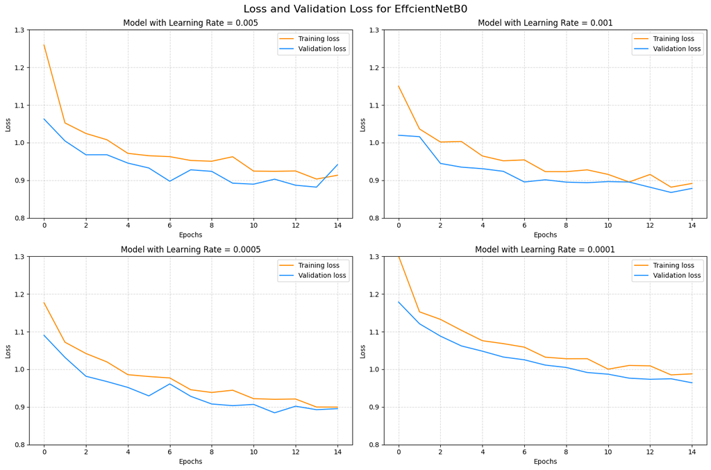

```python
# Plot the loss and validation loss for each learning rate in separate plots in a 2 by 2 grid
fig, axs = plt.subplots(2, 2, figsize = (15, 10))
epochs = range(len(train_loss_lr1))
ylim = (0.8, 1.3)

# Plot for lr1
axs[0, 0].plot(epochs, train_loss_lr1, 'darkorange', label = 'Training loss')
axs[0, 0].plot(epochs, val_loss_lr1, 'dodgerblue', label = 'Validation loss')
axs[0, 0].set_title(f'Model with Learning Rate = {lr1}')
axs[0, 0].set_xlabel('Epochs')
axs[0, 0].set_ylabel('Loss')
axs[0, 0].grid(alpha = 0.5, linestyle = '--')
axs[0, 0].set_ylim(ylim)
axs[0, 0].legend()

# Plot for lr2
axs[0, 1].plot(epochs, train_loss_lr2, 'darkorange', label = 'Training loss')
axs[0, 1].plot(epochs, val_loss_lr2, 'dodgerblue', label = 'Validation loss')
axs[0, 1].set_title(f'Model with Learning Rate = {lr2}')
axs[0, 1].set_xlabel('Epochs')
axs[0, 1].set_ylabel('Loss')
axs[0, 1].grid(alpha = 0.5, linestyle = '--')
axs[0, 1].set_ylim(ylim)
axs[0, 1].legend()

# Plot for lr3
axs[1, 0].plot(epochs, train_loss_lr3, 'darkorange', label = 'Training loss')
axs[1, 0].plot(epochs, val_loss_lr3, 'dodgerblue', label = 'Validation loss')
axs[1, 0].set_title(f'Model with Learning Rate = {lr3}')
axs[1, 0].set_xlabel('Epochs')
axs[1, 0].set_ylabel('Loss')
axs[1, 0].grid(alpha = 0.5, linestyle = '--')
axs[1, 0].set_ylim(ylim)
axs[1, 0].legend()

# Plot for lr4
axs[1, 1].plot(epochs, train_loss_lr4, 'darkorange', label = 'Training loss')
axs[1, 1].plot(epochs, val_loss_lr4, 'dodgerblue', label = 'Validation loss')
axs[1, 1].set_title(f'Model with Learning Rate = {lr4}')
axs[1, 1].set_xlabel('Epochs')
axs[1, 1].set_ylabel('Loss')
axs[1, 1].grid(alpha = 0.5, linestyle = '--')
axs[1, 1].set_ylim(ylim)
axs[1, 1].legend()

plt.suptitle(f'Loss and Validation Loss for EffcientNetB0', fontsize = 16)

plt.tight_layout()
plt.show()
```

Of the 4 learning rates, we see here that none of them are too high to overshoot a minimum, but at the same time that 0.001 is giving the fastest rate of conergence/decrease in validation loss.

## EfficientNet B2

```python
# Reformat validation set
X_spect_val_mod = val_data_processor(X_spect_val, 260)
```

```python
# Define your three learning rates
lr1 = 0.005
lr2 = 0.001
lr3 = 0.0005
lr4 = 0.0001

# Initialize lists to store training and validation loss for each learning rate
train_loss_lr1, val_loss_lr1 = [], []
train_loss_lr2, val_loss_lr2 = [], []
train_loss_lr3, val_loss_lr3 = [], []
train_loss_lr4, val_loss_lr4 = [], []

# Iterate over learning rates
learning_rates = [lr1, lr2, lr3, lr4]
for lr in learning_rates:
    model = build_en(model_type = 'B2', dense_layers = 1,
                     dense_cells = [50], activation = 'relu', lr = lr)

    # Initialize lists to store training and validation loss
    train_loss = []
    val_loss = []

    # Iterate over epochs and batches
    batch_size = 2906
    data_loader = CustomDataLoader(X_spect_train, y_train, batch_size, 260)
    initial_epoch = 0
    for num_epochs in range(5):
        for batch_data, batch_labels in data_loader:
            history = model.fit(batch_data, batch_labels, validation_data = (X_spect_val_mod, y_val),
                                batch_size = 32, epochs = initial_epoch + 1, verbose = False,
                                initial_epoch = initial_epoch)

            # Append the training and validation loss to the lists
            train_loss.append(history.history['loss'])
            val_loss.append(history.history['val_loss'])

            initial_epoch += 1
            gc.collect()

    # Append losses for current learning rate to respective lists
    if lr == lr1:
        train_loss_lr1.extend(train_loss)
        val_loss_lr1.extend(val_loss)
    elif lr == lr2:
        train_loss_lr2.extend(train_loss)
        val_loss_lr2.extend(val_loss)
    elif lr == lr3:
        train_loss_lr3.extend(train_loss)
        val_loss_lr3.extend(val_loss)
    else:
        train_loss_lr4.extend(train_loss)
        val_loss_lr4.extend(val_loss)
```

[output not shown]

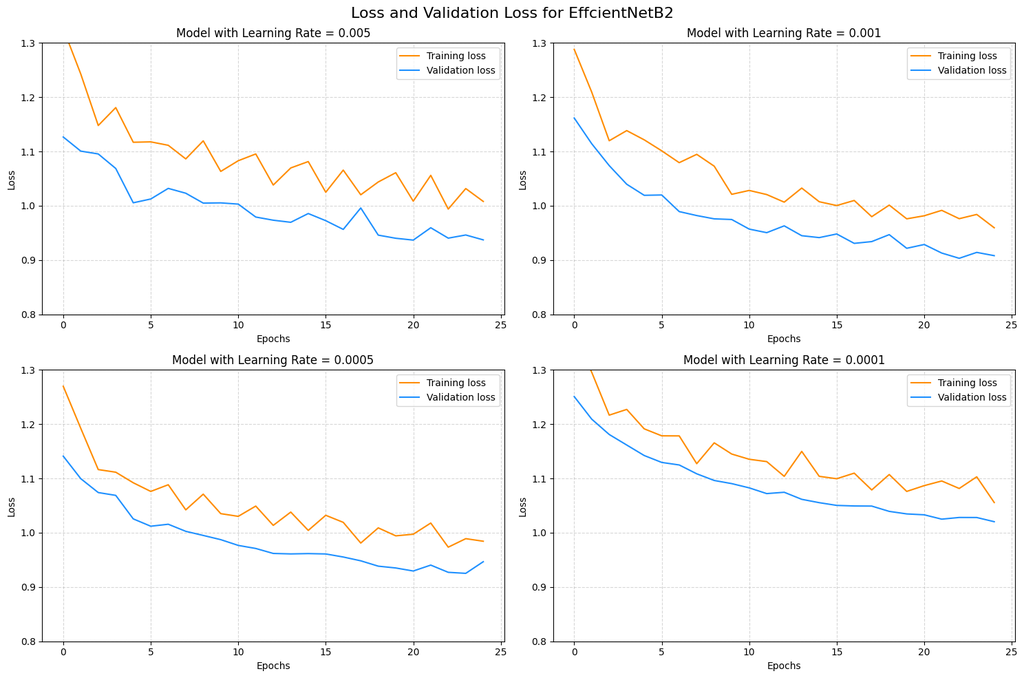

```python
# Plot the loss and validation loss for each learning rate in separate plots in a 2 by 2 grid
fig, axs = plt.subplots(2, 2, figsize = (15, 10))
epochs = range(len(train_loss_lr1))
ylim = (0.8, 1.3)

# Plot for lr1
axs[0, 0].plot(epochs, train_loss_lr1, 'darkorange', label = 'Training loss')
axs[0, 0].plot(epochs, val_loss_lr1, 'dodgerblue', label = 'Validation loss')
axs[0, 0].set_title(f'Model with Learning Rate = {lr1}')
axs[0, 0].set_xlabel('Epochs')
axs[0, 0].set_ylabel('Loss')
axs[0, 0].grid(alpha = 0.5, linestyle = '--')
axs[0, 0].set_ylim(ylim)
axs[0, 0].legend()

# Plot for lr2
axs[0, 1].plot(epochs, train_loss_lr2, 'darkorange', label = 'Training loss')
axs[0, 1].plot(epochs, val_loss_lr2, 'dodgerblue', label = 'Validation loss')
axs[0, 1].set_title(f'Model with Learning Rate = {lr2}')
axs[0, 1].set_xlabel('Epochs')
axs[0, 1].set_ylabel('Loss')
axs[0, 1].grid(alpha = 0.5, linestyle = '--')
axs[0, 1].set_ylim(ylim)
axs[0, 1].legend()

# Plot for lr3
axs[1, 0].plot(epochs, train_loss_lr3, 'darkorange', label = 'Training loss')
axs[1, 0].plot(epochs, val_loss_lr3, 'dodgerblue', label = 'Validation loss')
axs[1, 0].set_title(f'Model with Learning Rate = {lr3}')
axs[1, 0].set_xlabel('Epochs')
axs[1, 0].set_ylabel('Loss')
axs[1, 0].grid(alpha = 0.5, linestyle = '--')
axs[1, 0].set_ylim(ylim)
axs[1, 0].legend()

# Plot for lr4
axs[1, 1].plot(epochs, train_loss_lr4, 'darkorange', label = 'Training loss')
axs[1, 1].plot(epochs, val_loss_lr4, 'dodgerblue', label = 'Validation loss')
axs[1, 1].set_title(f'Model with Learning Rate = {lr4}')
axs[1, 1].set_xlabel('Epochs')
axs[1, 1].set_ylabel('Loss')
axs[1, 1].grid(alpha = 0.5, linestyle = '--')
axs[1, 1].set_ylim(ylim)
axs[1, 1].legend()

plt.suptitle(f'Loss and Validation Loss for EffcientNetB2', fontsize = 16)

plt.tight_layout()
plt.show()
```

After trying a more complex model, we see that the performance is worse, but not by a large margin. We also notice that the best performance is achieved at a learning rate of 0.001, similar to EfficientNet B0. As such, although we can say that 0.001 is a good learning rate to try out on a first run, we don't know definitively which model complexity is best. As a result, we turn next to trying out both EfficientNet B3 and B1 using this learning rate, to choose from the four models.

## Other Models: EfficientNet B3 & B1

```python
# Reformat validation set
X_spect_val_mod = val_data_processor(X_spect_val, 300)
```

```python
lr = 0.001
model = build_en(model_type = 'B3', dense_layers = 1,
                 dense_cells = [50], activation = 'relu', lr = lr)

# Initialize lists to store training and validation loss
train_loss_b3 = []
val_loss_b3 = []

# Iterate over epochs and batches
batch_size = 1500
data_loader = CustomDataLoader(X_spect_train, y_train, batch_size, 300)
initial_epoch = 0
for num_epochs in range(5):
    for batch_data, batch_labels in data_loader:
        history = model.fit(batch_data, batch_labels, validation_data = (X_spect_val_mod, y_val),
                            batch_size = 32, epochs = initial_epoch + 1, verbose = False,
                            initial_epoch = initial_epoch)

        # Append the training and validation loss to the lists
        train_loss_b3.append(history.history['loss'])
        val_loss_b3.append(history.history['val_loss'])

        initial_epoch += 1
        gc.collect()
```

```
2024-03-14 08:13:36.971975: E tensorflow/core/grappler/optimizers/meta_optimizer.cc:961] layout failed: INVALID_ARGUMENT: Size of values 0 does not match size of permutation 4 @ fanin shape inmodel_4/efficientnet-b3/block1b_drop/dropout/SelectV2-2-TransposeNHWCToNCHW-LayoutOptimizer
```

```python
# Reformat validation set
X_spect_val_mod = val_data_processor(X_spect_val, 240)
```

```python
lr = 0.001
model = build_en(model_type = 'B1', dense_layers = 1,
                 dense_cells = [50], activation = 'relu', lr = lr)

# Initialize lists to store training and validation loss
train_loss_b1 = []
val_loss_b1 = []

# Iterate over epochs and batches
batch_size = 3632
data_loader = CustomDataLoader(X_spect_train, y_train, batch_size, 240)
initial_epoch = 0
for num_epochs in range(5):
    for batch_data, batch_labels in data_loader:
        history = model.fit(batch_data, batch_labels, validation_data = (X_spect_val_mod, y_val),
                            batch_size = 32, epochs = initial_epoch + 1, verbose = False,
                            initial_epoch = initial_epoch)

        # Append the training and validation loss to the lists
        train_loss_b1.append(history.history['loss'])
        val_loss_b1.append(history.history['val_loss'])

        initial_epoch += 1
        gc.collect()
```

```
2024-03-14 08:37:50.397749: E tensorflow/core/grappler/optimizers/meta_optimizer.cc:961] layout failed: INVALID_ARGUMENT: Size of values 0 does not match size of permutation 4 @ fanin shape inmodel_5/efficientnet-b1/block1b_drop/dropout/SelectV2-2-TransposeNHWCToNCHW-LayoutOptimizer
```

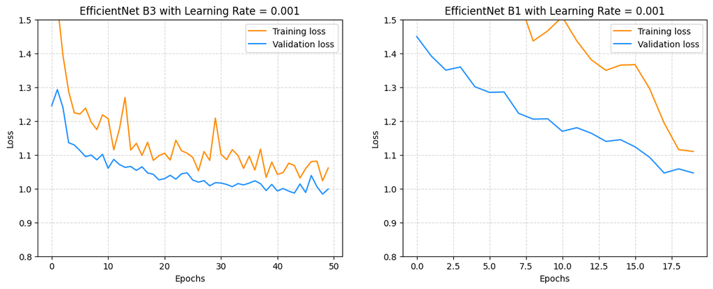

```python
epochs_b3 = range(len(train_loss_b3))
epochs_b1 = range(len(train_loss_b1))
ylim = (0.8, 1.5)

plt.figure(figsize = (14, 5))

# Plotting B3 results
plt.subplot(1, 2, 1)
plt.plot(epochs_b3, train_loss_b3, 'darkorange', label = 'Training loss')
plt.plot(epochs_b3, val_loss_b3, 'dodgerblue', label = 'Validation loss')
plt.title('EfficientNet B3 with Learning Rate = 0.001')
plt.xlabel('Epochs')
plt.ylabel('Loss')
plt.grid(alpha = 0.5, linestyle = '--')
plt.ylim(ylim)
plt.legend()

# Plotting B1 results
plt.subplot(1, 2, 2)
plt.plot(epochs_b1, train_loss_b1, 'darkorange', label = 'Training loss')
plt.plot(epochs_b1, val_loss_b1, 'dodgerblue', label = 'Validation loss')
plt.title('EfficientNet B1 with Learning Rate = 0.001')
plt.xlabel('Epochs')
plt.ylabel('Loss')
plt.grid(alpha = 0.5, linestyle = '--')
plt.ylim(ylim)
plt.legend()

plt.show()
```

Both models are remarkably worse, so the competition is definitely between B0 and B2. I chose to go ahead with B0 as it's the most time efficient to train out of all of them, and it outperformed all of the ther models in terms of validation loss. Given this model, we can now start selecting the proper dense-layer architecture.

# [4]. Narrowing Down Architecture Selection

For this portion of the analysis, I chose to test the following dense layer architectures:

- Architecture A: 1 Layer, 25 Cells.
- Architecture B: 1 Layer, 50 Cells.
- Architecture C: 1 Layer, 100 Cells.
- Architecture D: 2 Layers, 25 and 10 Cells, respectively.

Smaller layers mean that we are consolidating the information learned from EfficientNet into fewer "features" before inferring classes from them, and vice versa for larger layers. I tried a two layer approach as well to see if a hierarchy of features learned from EfficientNet might be of use in the classfication task.

```python
# Reformat validation set
X_spect_val_mod = val_data_processor(X_spect_val, 224)
```

```python
arch_a = ("A", 1, [25])
arch_b = ("B", 1, [50])
arch_c = ("C", 1, [100])
arch_d = ("D", 2, [25, 10])

# Initialize lists to store training and validation loss for each learning rate
train_loss_a, val_loss_a = [], []
train_loss_b, val_loss_b = [], []
train_loss_c, val_loss_c = [], []
train_loss_d, val_loss_d = [], []

# Iterate over learning rates
architectures = [arch_a, arch_b, arch_c, arch_d]
for arch in architectures:
    model = build_en(model_type = 'B0', dense_layers = arch[1], dense_cells = arch[2],
                     activation = 'relu', lr = 0.001)

    # Initialize lists to store training and validation loss
    train_loss = []
    val_loss = []

    # Iterate over epochs and batches
    batch_size = 3632
    data_loader = CustomDataLoader(X_spect_train, y_train, batch_size, 224)
    initial_epoch = 0
    for num_epochs in range(5):
        for batch_data, batch_labels in data_loader:
            history = model.fit(batch_data, batch_labels, validation_data = (X_spect_val_mod, y_val),
                                batch_size = 32, epochs = initial_epoch + 1, verbose = False,
                                initial_epoch = initial_epoch)

            # Append the training and validation loss to the lists
            train_loss.append(history.history['loss'])
            val_loss.append(history.history['val_loss'])

            initial_epoch += 1
            gc.collect()

    # Append losses to respective lists
    if arch[0] == "A":
        train_loss_a.extend(train_loss)
        val_loss_a.extend(val_loss)
    elif arch[0] == "B":
        train_loss_b.extend(train_loss)
        val_loss_b.extend(val_loss)
    elif arch[0] == "C":
        train_loss_c.extend(train_loss)
        val_loss_c.extend(val_loss)
    else:
        train_loss_d.extend(train_loss)
        val_loss_d.extend(val_loss)
```

[output not shown]

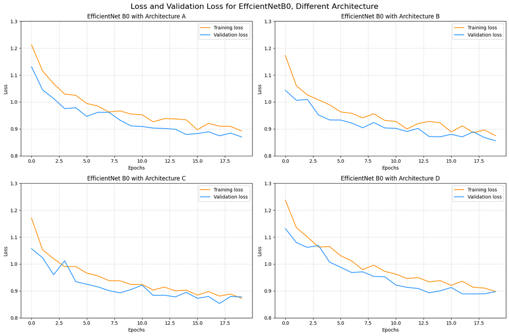

```python
# Plot the loss and validation loss for each learning rate in separate plots in a 2 by 2 grid
fig, axs = plt.subplots(2, 2, figsize = (15, 10))
epochs = range(len(train_loss_a))
ylim = (0.8, 1.3)

axs[0, 0].plot(epochs, train_loss_a, 'darkorange', label = 'Training loss')
axs[0, 0].plot(epochs, val_loss_a, 'dodgerblue', label = 'Validation loss')
axs[0, 0].set_title('EfficientNet B0 with Architecture A')
axs[0, 0].set_xlabel('Epochs')
axs[0, 0].set_ylabel('Loss')
axs[0, 0].grid(alpha = 0.5, linestyle = '--')
axs[0, 0].set_ylim(ylim)
axs[0, 0].legend()

axs[0, 1].plot(epochs, train_loss_b, 'darkorange', label = 'Training loss')
axs[0, 1].plot(epochs, val_loss_b, 'dodgerblue', label = 'Validation loss')
axs[0, 1].set_title('EfficientNet B0 with Architecture B')
axs[0, 1].set_xlabel('Epochs')
axs[0, 1].set_ylabel('Loss')
axs[0, 1].grid(alpha = 0.5, linestyle = '--')
axs[0, 1].set_ylim(ylim)
axs[0, 1].legend()

axs[1, 0].plot(epochs, train_loss_c, 'darkorange', label = 'Training loss')
axs[1, 0].plot(epochs, val_loss_c, 'dodgerblue', label = 'Validation loss')
axs[1, 0].set_title('EfficientNet B0 with Architecture C')
axs[1, 0].set_xlabel('Epochs')
axs[1, 0].set_ylabel('Loss')
axs[1, 0].grid(alpha = 0.5, linestyle = '--')
axs[1, 0].set_ylim(ylim)
axs[1, 0].legend()

axs[1, 1].plot(epochs, train_loss_d, 'darkorange', label = 'Training loss')
axs[1, 1].plot(epochs, val_loss_d, 'dodgerblue', label = 'Validation loss')
axs[1, 1].set_title('EfficientNet B0 with Architecture D')
axs[1, 1].set_xlabel('Epochs')
axs[1, 1].set_ylabel('Loss')
axs[1, 1].grid(alpha = 0.5, linestyle = '--')
axs[1, 1].set_ylim(ylim)
axs[1, 1].legend()

plt.suptitle(f'Loss and Validation Loss for EffcientNetB0, Different Architecture', fontsize = 16)

plt.tight_layout()
plt.show()
```

# [5]. Tune Learning Rate

From previous analysis, we see that (by a slim margin) Architecture B with 50 cells in one dense layer performed best. Next, it's useful to narrow down the scope of our used learning rate even more, and do another round of tuning. We do this as most of the network's hyperparameter options have finally been fixed, and we can focus on finding the optimal step given the choices made for this specific network.

```python
# Define your three learning rates
lr1 = 0.004
lr2 = 0.002
lr3 = 0.0009
lr4 = 0.0007

# Initialize lists to store training and validation loss for each learning rate
train_loss_lr1, val_loss_lr1 = [], []
train_loss_lr2, val_loss_lr2 = [], []
train_loss_lr3, val_loss_lr3 = [], []
train_loss_lr4, val_loss_lr4 = [], []

# Iterate over learning rates
learning_rates = [lr1, lr2, lr3, lr4]
for lr in learning_rates:
    model = build_en(model_type = 'B0', dense_layers = 1, dense_cells = [50],
                     activation = 'relu', lr = lr)

    # Initialize lists to store training and validation loss
    train_loss = []
    val_loss = []

    # Iterate over epochs and batches
    batch_size = 3632
    data_loader = CustomDataLoader(X_spect_train, y_train, batch_size, 224)
    initial_epoch = 0
    for num_epochs in range(5):
        for batch_data, batch_labels in data_loader:
            history = model.fit(batch_data, batch_labels, validation_data = (X_spect_val_mod, y_val),
                                batch_size = 32, epochs = initial_epoch + 1, verbose = False,
                                initial_epoch = initial_epoch)

            # Append the training and validation loss to the lists
            train_loss.append(history.history['loss'])
            val_loss.append(history.history['val_loss'])

            initial_epoch += 1
            gc.collect()

    # Append losses for current learning rate to respective lists
    if lr == lr1:
        train_loss_lr1.extend(train_loss)
        val_loss_lr1.extend(val_loss)
    elif lr == lr2:
        train_loss_lr2.extend(train_loss)
        val_loss_lr2.extend(val_loss)
    elif lr == lr3:
        train_loss_lr3.extend(train_loss)
        val_loss_lr3.extend(val_loss)
    else:
        train_loss_lr4.extend(train_loss)
        val_loss_lr4.extend(val_loss)
```

[output not shown]

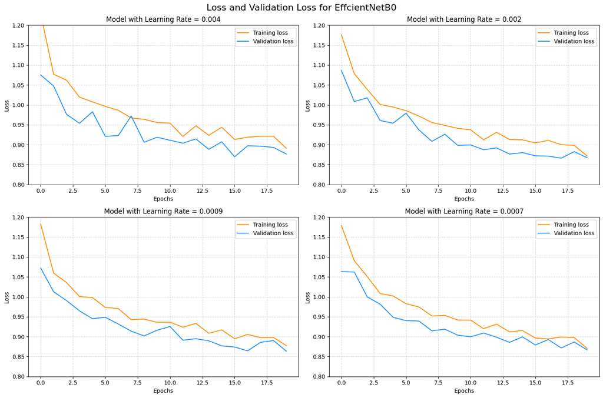

```python
# Plot the loss and validation loss for each learning rate in separate plots in a 2 by 2 grid
fig, axs = plt.subplots(2, 2, figsize = (15, 10))
epochs = range(len(train_loss_lr1))
ylim = (0.8, 1.2)

# Plot for lr1
axs[0, 0].plot(epochs, train_loss_lr1, 'darkorange', label = 'Training loss')
axs[0, 0].plot(epochs, val_loss_lr1, 'dodgerblue', label = 'Validation loss')
axs[0, 0].set_title(f'Model with Learning Rate = {lr1}')
axs[0, 0].set_xlabel('Epochs')
axs[0, 0].set_ylabel('Loss')
axs[0, 0].grid(alpha = 0.5, linestyle = '--')
axs[0, 0].set_ylim(ylim)
axs[0, 0].legend()

# Plot for lr2
axs[0, 1].plot(epochs, train_loss_lr2, 'darkorange', label = 'Training loss')
axs[0, 1].plot(epochs, val_loss_lr2, 'dodgerblue', label = 'Validation loss')
axs[0, 1].set_title(f'Model with Learning Rate = {lr2}')
axs[0, 1].set_xlabel('Epochs')
axs[0, 1].set_ylabel('Loss')
axs[0, 1].grid(alpha = 0.5, linestyle = '--')
axs[0, 1].set_ylim(ylim)
axs[0, 1].legend()

# Plot for lr3
axs[1, 0].plot(epochs, train_loss_lr3, 'darkorange', label = 'Training loss')
axs[1, 0].plot(epochs, val_loss_lr3, 'dodgerblue', label = 'Validation loss')
axs[1, 0].set_title(f'Model with Learning Rate = {lr3}')
axs[1, 0].set_xlabel('Epochs')
axs[1, 0].set_ylabel('Loss')
axs[1, 0].grid(alpha = 0.5, linestyle = '--')
axs[1, 0].set_ylim(ylim)
axs[1, 0].legend()

# Plot for lr4
axs[1, 1].plot(epochs, train_loss_lr4, 'darkorange', label = 'Training loss')
axs[1, 1].plot(epochs, val_loss_lr4, 'dodgerblue', label = 'Validation loss')
axs[1, 1].set_title(f'Model with Learning Rate = {lr4}')
axs[1, 1].set_xlabel('Epochs')
axs[1, 1].set_ylabel('Loss')
axs[1, 1].grid(alpha = 0.5, linestyle = '--')
axs[1, 1].set_ylim(ylim)
axs[1, 1].legend()

plt.suptitle(f'Loss and Validation Loss for EffcientNetB0', fontsize = 16)

plt.tight_layout()
plt.show()
```

# [6]. Does Swish Make Life Easier?

Many recent studies claim that Swish, an activation function who's derivative is the sigmoid, outperforms ReLU in most tasks. Swish is characterized by its smoothness and differentiability, making it a viable alternative to Rectified Linear Unit (ReLU), which has been a popular choice for many years. We will switch the ReLu activations with Swish to see if we can gain a tiny bit more improvment in performance by using it. The debate surrounding activation functions in neural networks is ongoing, with researchers continually exploring new options to improve model performance.

One of the key advantages of Swish is, as mentioned previously, its derivative being related to the sigmoid function, which helps mitigate the vanishing gradient problem encountered in deep neural networks. This property enables smoother and more stable gradient flow during training, potentially leading to faster convergence and better generalization on various tasks.

```python
model = build_en(model_type = 'B0', dense_layers = 1, dense_cells = [50],
                 activation = 'swish', lr = 0.0007)

# Initialize lists to store training and validation loss
train_loss_swish = []
val_loss_swish = []

# Iterate over epochs and batches
batch_size = 3632
data_loader = CustomDataLoader(X_spect_train, y_train, batch_size, 224)
initial_epoch = 0
for num_epochs in range(9):
    for batch_data, batch_labels in data_loader:
        history = model.fit(batch_data, batch_labels, validation_data = (X_spect_val_mod, y_val),
                            batch_size = 32, epochs = initial_epoch + 1, verbose = False,
                            initial_epoch = initial_epoch)

        # Append the training and validation loss to the lists
        train_loss_swish.append(history.history['loss'])
        val_loss_swish.append(history.history['val_loss'])

        initial_epoch += 1
        gc.collect()
```

```
2024-03-14 09:36:09.139139: E tensorflow/core/grappler/optimizers/meta_optimizer.cc:961] layout failed: INVALID_ARGUMENT: Size of values 0 does not match size of permutation 4 @ fanin shape inmodel_14/efficientnet-b0/block2b_drop/dropout/SelectV2-2-TransposeNHWCToNCHW-LayoutOptimizer
```

```python
model = build_en(model_type = 'B0', dense_layers = 1, dense_cells = [50],
                 activation = 'relu', lr = 0.0007)

# Initialize lists to store training and validation loss
train_loss_relu = []
val_loss_relu = []

# Iterate over epochs and batches
batch_size = 3632
data_loader = CustomDataLoader(X_spect_train, y_train, batch_size, 224)
initial_epoch = 0
for num_epochs in range(9):
    for batch_data, batch_labels in data_loader:
        history = model.fit(batch_data, batch_labels, validation_data = (X_spect_val_mod, y_val),
                            batch_size = 32, epochs = initial_epoch + 1, verbose = False,
                            initial_epoch = initial_epoch)

        # Append the training and validation loss to the lists
        train_loss_relu.append(history.history['loss'])
        val_loss_relu.append(history.history['val_loss'])

        initial_epoch += 1
        gc.collect()
```

```
2024-03-14 09:49:12.440207: E tensorflow/core/grappler/optimizers/meta_optimizer.cc:961] layout failed: INVALID_ARGUMENT: Size of values 0 does not match size of permutation 4 @ fanin shape inmodel_15/efficientnet-b0/block2b_drop/dropout/SelectV2-2-TransposeNHWCToNCHW-LayoutOptimizer
```

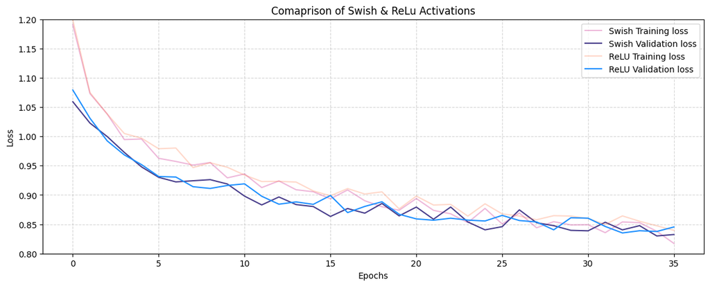

```python
epochs = range(len(train_loss_swish))
ylim = (0.8, 1.2)

plt.figure(figsize = (14, 5))

# Plotting side by side results
plt.plot(epochs, train_loss_swish, 'mediumvioletred', label = 'Swish Training loss', alpha = 0.3)
plt.plot(epochs, val_loss_swish, 'darkslateblue', label = 'Swish Validation loss')
plt.plot(epochs, train_loss_relu, 'coral', label = 'ReLU Training loss', alpha = 0.3)
plt.plot(epochs, val_loss_relu, 'dodgerblue', label = 'ReLU Validation loss')
plt.title('Comaprison of Swish & ReLu Activations')
plt.xlabel('Epochs')
plt.ylabel('Loss')
plt.grid(alpha = 0.5, linestyle = '--')
plt.ylim(ylim)
plt.legend()

plt.show()
```

We see that Swish did indeed perform slightly better than ReLU, and so we can adopt it for this neural network. The activation is a lot more computationally costly than ReLU (which has derivatives either 0 or 1), but given the computational resources at hand it is reasonable to resort to its use.

# [7]. Train Final Model

We train our final model with the hyperparameters chosen from previous parts, trained for 60 epochs or until there is no improvement noticeable in our validation loss. We monitor improvement by using an early stopping callback, but in our case we didn't even resort to activating it.

```python
model = build_en(model_type = 'B0', dense_layers = 1, dense_cells = [50],
                 activation = 'swish', lr = 0.0007)

# Initialize lists to store training and validation loss
train_loss = []
val_loss = []

early_stopping = tf.keras.callbacks.EarlyStopping(monitor = 'val_loss', patience = 3, restore_best_weights = True)


# Iterate over epochs and batches
batch_size = 7264
data_loader = CustomDataLoader(X_spect_train, y_train, batch_size, 224)
initial_epoch = 0
for num_epochs in range(30):
    for batch_data, batch_labels in data_loader:
        history = model.fit(batch_data, batch_labels, validation_data = (X_spect_val_mod, y_val),
                            batch_size = 32, epochs = initial_epoch + 1, verbose = True,
                            initial_epoch = initial_epoch, callbacks = [early_stopping])

        # Append the training and validation loss to the lists
        train_loss.append(history.history['loss'])
        val_loss.append(history.history['val_loss'])

        initial_epoch += 1
        gc.collect()
```

```
2024-03-14 10:04:05.518599: E tensorflow/core/grappler/optimizers/meta_optimizer.cc:961] layout failed: INVALID_ARGUMENT: Size of values 0 does not match size of permutation 4 @ fanin shape inmodel/efficientnet-b0/block2b_drop/dropout/SelectV2-2-TransposeNHWCToNCHW-LayoutOptimizer
WARNING: All log messages before absl::InitializeLog() is called are written to STDERR
I0000 00:00:1710410648.999516     113 device_compiler.h:186] Compiled cluster using XLA!  This line is logged at most once for the lifetime of the process.
```

```python
# Save best model
model.save('/kaggle/working/cnn_model.keras')
```